# IODS course project

- Therefore, gender and/or strategic question answers should not have significant difference with points on the exam.
- Estimate 3.5100 means that when attitude increases by one, the points in the exam increase by 3.5100.
- R-squared tells about the fit of the model, which in here is 0.1904. It means that the estimates do not follow nicely the regression line, but that there is variance. Maybe another explanatory variables could be added..?

Due to these results, gender and strategic questions are deleted from the model.

```r
#Calculating another model and summary statistics
my_model2 <-lm(points ~ attitude, data = data)
summary(my_model2)
```

```
##
## Call:
## lm(formula = points ~ attitude, data = data)
##
## Residuals:
##      Min       1Q   Median       3Q      Max
## -16.9763  -3.2119   0.4339   4.1534  10.6645
##
## Coefficients:
##             Estimate Std. Error t value Pr(>|t|)
## (Intercept)  11.6372     1.8303   6.358 1.95e-09 ***
## attitude      3.5255     0.5674   6.214 4.12e-09 ***
## ---
## Signif. codes:  0 '***' 0.001 '**' 0.01 '*' 0.05 '.' 0.1 ' ' 1
##
## Residual standard error: 5.32 on 164 degrees of freedom
## Multiple R-squared:  0.1906, Adjusted R-squared:  0.1856
## F-statistic: 38.61 on 1 and 164 DF,  p-value: 4.119e-09
```

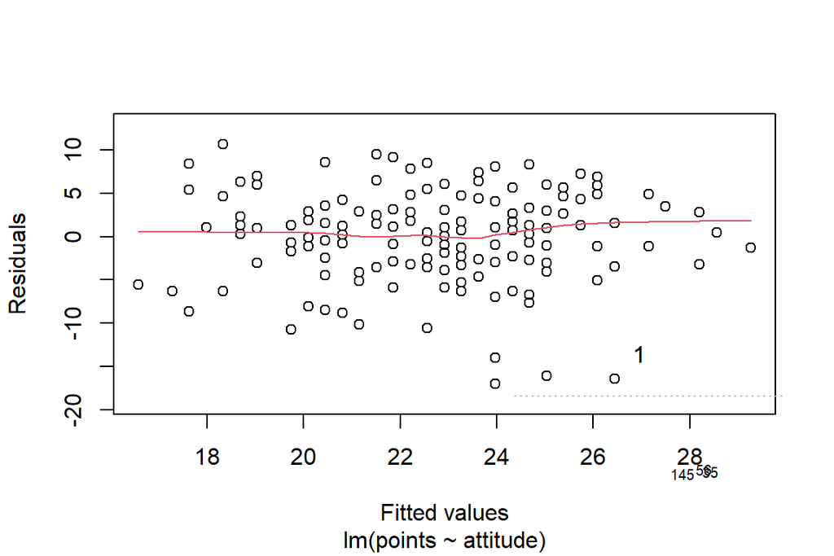

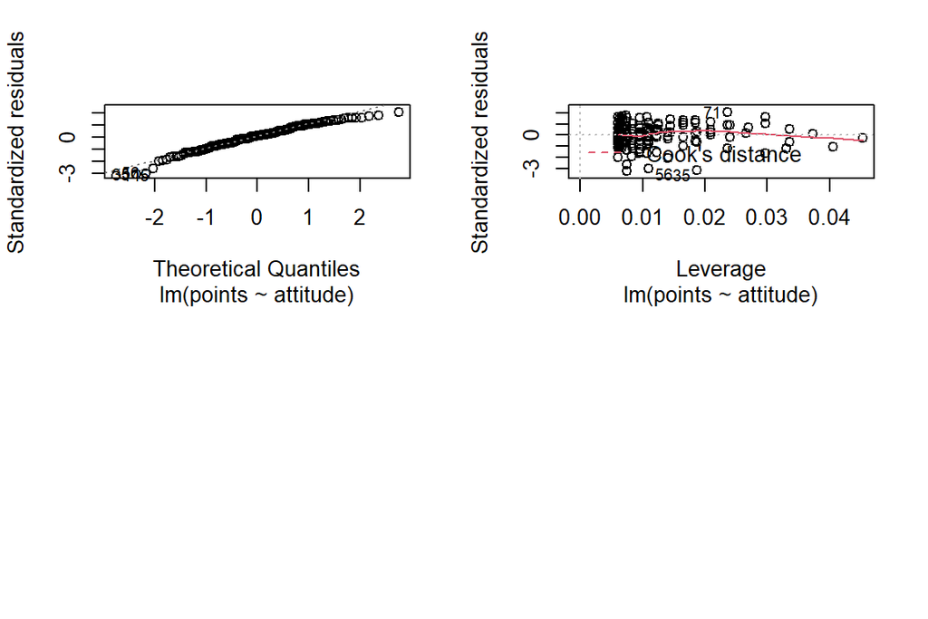

```r
# Diagnostic plots to check the validity of the model
plot(my_model2, which = c(1,2,5), par(mfrow = c(2,2)))
```

Since linear regression models assume the errors to be normally distributed, not to be correlated and to have a constant variance, the residuals can be used to confirm these assumptions.

- Based on the diagnostic plots (Residuals vs Fitted values, Normal QQ-plot and Residuals vs Leverage), the residuals follow quite well the normal distribution.
- However, the variance of the residuals is not fully constant.
- The leverage plot shows that some values have more leverage than other values. Therefore some outliers could maybe be excluded.

**Until next week**

# Logistic regression (week 3)

> *This week continued with data wrangling. Logistic regression was introduced to study alcohol consumption*

In this exercise, data from Machine Learning repository was downloaded. More information from the data is found in [here](https://archive.ics.uci.edu/ml/datasets/Student+Performance).

The data was used to study student performance on math and portuguese exams. Here, the data is used to study which factors may explain high or low alcohol consumption. High alcohol consumption is defined from alcohol use, calculated as average from weekend and workday alcohol consumption (measured in scale from 1 being very low to 5 being very high). High alcohol consumption (TRUE) is defined as > 2 points.

```r
#Making the data easier to observe by dropping some columns not needed
pormath <-read.csv("pormath.csv")
data <- select(pormath, sex, famsup, failures, internet, high_use, alc_use)
head(data, n=3)
```

```
##   sex famsup failures internet high_use alc_use
## 1   F    yes        0      yes    FALSE       1
## 2   F    yes        1      yes     TRUE       3
## 3   F    yes        0       no    FALSE       1
```

```r
data$failures <- as.factor(data$failures)
str(data)
```

```
## 'data.frame':    370 obs. of  6 variables:
##  $ sex     : chr  "F" "F" "F" "F" ...
##  $ famsup  : chr  "yes" "yes" "yes" "yes" ...
##  $ failures: Factor w/ 4 levels "0","1","2","3": 1 2 1 1 2 1 2 1 1 1 ...
##  $ internet: chr  "yes" "yes" "no" "yes" ...
##  $ high_use: logi  FALSE TRUE FALSE FALSE TRUE FALSE ...
##  $ alc_use : num  1 3 1 1 2.5 1 2 2 2.5 1 ...
```

The studied explanatory variables are sex, access to internet at home, class failures and family support. Sex-specific differences may occur, internet access may reflect the environment where one lives, which again may be counteracted with family support. Class failures may reflect problems with school.

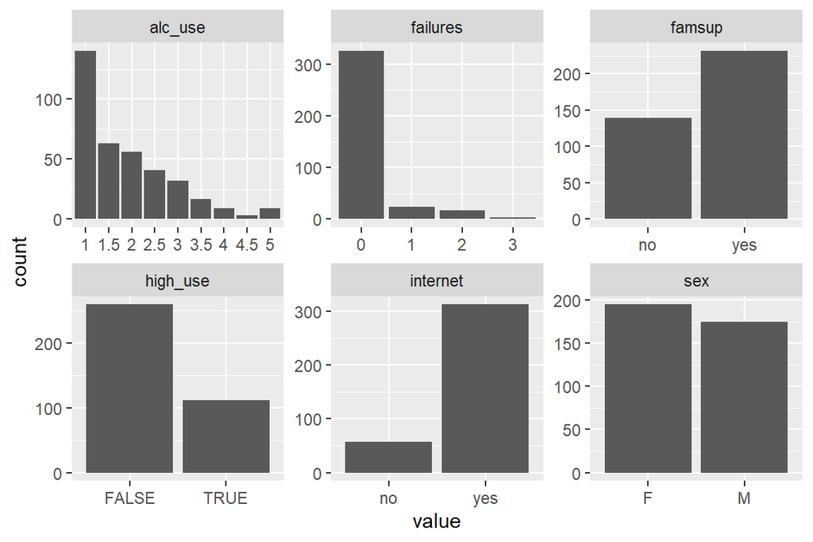

```r
#Observing how the data is distributed based on the variables
gather(data)  %>%
  ggplot(aes(value))+
  geom_bar()+
  facet_wrap("key", scales = "free")
```

There are less high alcohol users than low users, seen from both alc_use and high_use variables. Many of the students have not had failures in classes, and most of the students have access to internet. These may affect finding the best line, since some groups are under- and some over-presented. There are a bit more females in the data, than males.

```r
#Testing whether there is significant difference in persons high alcohol use and sex
tbl <- table(data$high_use, data$sex)
tbl
```

```
##
##           F   M
##   FALSE 154 105
##   TRUE   41  70
```

```r
chisq.test(tbl)
```

```
##
##  Pearson's Chi-squared test with Yates' continuity correction
##
## data:  tbl
## X-squared = 14.921, df = 1, p-value = 0.0001121
```

There is significant (p<0.001) difference between high/low alcohol use and sex. Less females belong to high alcohol users -group than males. Therefore, as hypothesized before, gender-specific differences do exist in the data.

Then, logistic regression analysis is performed to study how selected variables predict high/low alcohol use. High/low alcohol use is explained by sex, class failures, internet access in the home and family support

```r
#Calculating logistic regression model, where high alcohol use is explained by class
model <- glm(high_use ~ sex + failures + internet + famsup, data = data, family = "binomial")
summary(model)
```

```
##
## Call:
## glm(formula = high_use ~ sex + failures + internet + famsup,
##     family = "binomial", data = data)
##
## Deviance Residuals:
##     Min       1Q   Median       3Q      Max
## -1.8172  -0.9571  -0.6501   1.3062   1.9265
##
## Coefficients:
##             Estimate Std. Error z value Pr(>|z|)
## (Intercept) -1.67202    0.38058  -4.393 1.12e-05 ***
## sexM         0.90364    0.24405   3.703 0.000213 ***
## failures1    1.14568    0.43832   2.614 0.008954 **
## failures2    0.97496    0.51719   1.885 0.059413 .
## failures3    1.98133    1.19871   1.653 0.098356 .
## internetyes  0.23885    0.34642   0.689 0.490518
## famsupyes   -0.01363    0.24766  -0.055 0.956112
## ---
## Signif. codes:  0 '***' 0.001 '**' 0.01 '*' 0.05 '.' 0.1 ' ' 1
##
## (Dispersion parameter for binomial family taken to be 1)
##
##     Null deviance: 452.04  on 369  degrees of freedom
## Residual deviance: 423.49  on 363  degrees of freedom
## AIC: 437.49
##
## Number of Fisher Scoring iterations: 4
```

In this model, it is noticed that the deviance residuals are not totally symmetrical (on 1Q and 3Q).

```r
#Calculating pseudo-R^2 for the model
ll.null <- model$null.deviance/-2
ll.proposed <- model$deviance/-2

(ll.null-ll.proposed)/ ll.null
```

```
## [1] 0.06315082
```

```r
#Calculating p-value for the R^2
1-pchisq(2*(ll.proposed - ll.null), df=(length(model$coefficients)-1))
```

```
## [1] 7.410799e-05
```

For this model, the calculated R^2 is very small, so the model is not good for the intended use, even though the p-value is very small. Code for calculating the R^2 and p-value from [here](https://github.com/StatQuest/logistic_regression_demo/blob/master/logistic_regression_demo.R)

```r
#Then, calculating odds ratios and confidence intervals for those
OR <- coef(model)%>% exp
CI <- confint(model) %>% exp
(md1 <-cbind(OR, CI))
```

```
##                    OR      2.5 %      97.5 %
## (Intercept) 0.1878674 0.08619137   0.3856184
## sexM        2.4685624 1.53722862   4.0090586
## failures1   3.1445895 1.32245905   7.5059236
## failures2   2.6510714 0.95534979   7.4815719
## failures3   7.2523525 0.85514220 154.5866278
## internetyes 1.2697888 0.65678778   2.5747271
## famsupyes   0.9864628 0.60892949   1.6106286
```

The odds ratios (with respective confidence intervals) show that only for sex, and failure1 (compared to failure0) the CI doesn’t overlap 1, making them significant. Here, the odds ratio for being a male has 2,46 times higher odd for being high-alcohol consumer.

As previously stated, many class failures were included only for few students, with is here shown in very high confidence intervals.

Then, the model is calculated again, so that internet access and family support are taken away from the model.

```r
#Calculating logistic regression model, where high alcohol use is explained by class
model2 <- glm(high_use ~ sex + failures, data = data, family = "binomial")
summary(model2)
```

```
##
## Call:
## glm(formula = high_use ~ sex + failures, family = "binomial",
##     data = data)
##
## Deviance Residuals:
##     Min       1Q   Median       3Q      Max
## -1.7842  -0.9486  -0.6408   1.3243   1.8353
##
## Coefficients:
##             Estimate Std. Error z value Pr(>|z|)
## (Intercept)  -1.4789     0.1874  -7.891    3e-15 ***
## sexM          0.9136     0.2404   3.801 0.000144 ***
## failures1     1.1401     0.4401   2.590 0.009586 **
## failures2     0.9516     0.5138   1.852 0.064004 .
## failures3     1.9294     1.1823   1.632 0.102701
## ---
## Signif. codes:  0 '***' 0.001 '**' 0.01 '*' 0.05 '.' 0.1 ' ' 1
##
## (Dispersion parameter for binomial family taken to be 1)
##
##     Null deviance: 452.04  on 369  degrees of freedom
## Residual deviance: 423.98  on 365  degrees of freedom
## AIC: 433.98
##
## Number of Fisher Scoring iterations: 4
```

```r
#Calculating pseudo-R^2 for the model
ll.null2 <- model2$null.deviance/-2
ll.proposed2 <- model2$deviance/-2

(ll.null2-ll.proposed2)/ ll.null2
```

```
## [1] 0.06207403
```

```r
#Calculating p-value for the R^2
1-pchisq(2*(ll.proposed2 - ll.null2), df=(length(model2$coefficients)-1))
```

```
## [1] 1.212896e-05
```

Again, the R^2 is very small, even though the p-value is small, so high alcohol consumption is not explained by sex and failures at school. The estimators for sex and class failures do not change from the previous model.

```r
#Then, calculating odds ratios and confidence intervals for the updated model
OR <- coef(model2)%>% exp
CI <- confint(model2) %>% exp
(md2 <-cbind(OR, CI))
```

```
##                    OR     2.5 %      97.5 %
## (Intercept) 0.2278792 0.1555764   0.3250221
## sexM        2.4931754 1.5637633   4.0196560
## failures1   3.1270647 1.3110294   7.4920699
## failures2   2.5897545 0.9391678   7.2597990
## failures3   6.8855267 0.8334266 143.5470358
```

Here, still, males have app. 2,5 times odds for being high alcohol consumers.

The ability for this model to predic alcohol consumption is tested:

```r
# predict() the probability of high_use
probabilities <- predict(model2, type = "response")

# add the predicted probabilities to 'alc'
data <- mutate(data, probability = probabilities)
head(data)
```

```
##   sex famsup failures internet high_use alc_use probability
## 1   F    yes        0      yes    FALSE     1.0   0.1855876
## 2   F    yes        1      yes     TRUE     3.0   0.4160901
## 3   F    yes        0       no    FALSE     1.0   0.1855876
## 4   F    yes        0      yes    FALSE     1.0   0.1855876
## 5   F    yes        1      yes     TRUE     2.5   0.4160901
## 6   F    yes        0      yes    FALSE     1.0   0.1855876
```

```r
# use the probabilities to make a prediction of high_use
data <- mutate(data, prediction = probabilities >0.5)

# see the last ten original classes, predicted probabilities, and class predictions
select(data, sex, failures, high_use, probability, prediction) %>% tail(10)
```

```
##     sex failures high_use probability prediction
## 361   M        1     TRUE   0.6398498       TRUE
## 362   M        0     TRUE   0.3623030      FALSE
## 363   M        0     TRUE   0.3623030      FALSE
## 364   M        0     TRUE   0.3623030      FALSE
## 365   M        0    FALSE   0.3623030      FALSE
## 366   M        0     TRUE   0.3623030      FALSE
## 367   M        0    FALSE   0.3623030      FALSE
## 368   M        1     TRUE   0.6398498       TRUE
## 369   M        2     TRUE   0.5953629       TRUE
## 370   M        1    FALSE   0.6398498       TRUE
```

```r
# tabulate the target variable versus the predictions
table(high_use = data$high_use, prediction = data$prediction)
```

```
##         prediction
## high_use FALSE TRUE
##    FALSE   250    9
##    TRUE     95   16
```

If the model would be used for predicting the alcohol use, there would be much falsely predicted individuals.

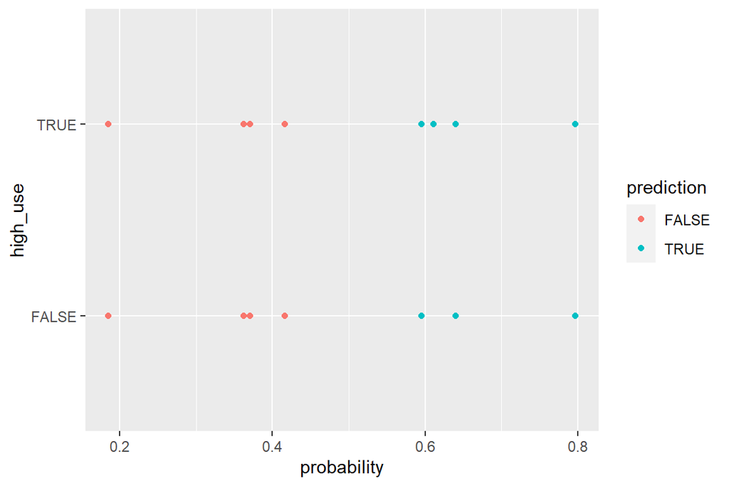

```r
g <- ggplot(data, aes(x = probability, y = high_use, col = prediction))

# define the geom as points and draw the plot
g + geom_point()
```

```r
# tabulate the target variable versus the predictions
table(high_use = data$high_use, prediction = data$prediction) %>%
prop.table %>%
addmargins
```

```
##         prediction
## high_use      FALSE       TRUE        Sum
##    FALSE 0.67567568 0.02432432 0.70000000
##    TRUE  0.25675676 0.04324324 0.30000000
##    Sum   0.93243243 0.06756757 1.00000000
```

```r
#Defining loss function for mean prediction error
loss_func <- function(class, prob) {
  n_wrong <- abs(class - prob) > 0.5
  mean(n_wrong)
}
loss_func(class = data$high_use, prob = data$probability)
```

```
## [1] 0.2810811
```

The model would cause 28 % of the predictions to be falsely predicted.

Lastly, the model is cross-validated to test the model in data the model has not seen before.

```r
#Crossvalidation: 10-fold validation
cv <- cv.glm(data = data, cost = loss_func, glmfit = model2, K = 10)

# average number of wrong predictions in the cross validation
cv$delta[1]
```

```
## [1] 0.2837838
```

The error is 29 % with the 10-fold cross-validated model.

Therefore, for predicting high-low alcohol consumption, another model should be used. It should be noticed, that the data is not “normally distributed”, since the different classes do not have similar amount of participants in them. This might lead to a biased model.

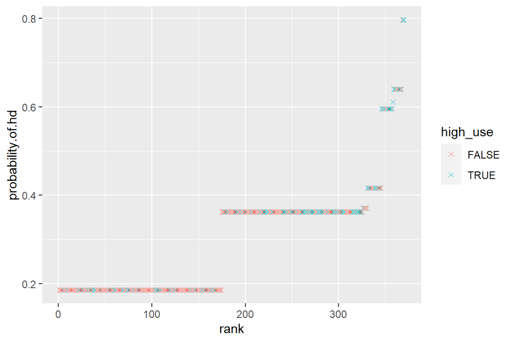

```r
#Plot test
predicted.data <- data.frame(
  probability.of.hd=model2$fitted.values,
  high_use=data$high_use
)
predicted.data <- predicted.data[ + order(predicted.data$probability.of.hd, decreasing = FALSE),]
predicted.data$rank <- 1:nrow(predicted.data)

ggplot(predicted.data, aes(x=rank, y=probability.of.hd, col = high_use))+
         geom_point(alpha =1, shape =4)
```

# Classification and clustering (week 4)

> *This week introduced classification and clustering methods, such as LDA and k-means clustering*

In this exercise, Boston data from R package MASS was used. The data includes housing values in suburbs of Boston, such as crime rate, owner occupied houses, pupil-teacher ratios and so on. More information regarding the data is found [here](https://stat.ethz.ch/R-manual/R-devel/library/MASS/html/Boston.html).

The Boston dataset includes 506 observations from 14 variables. For example, crim means per capita crime rate by town, chas closeness to Charles river, nox the nitrogen oxides concentration, and age is proportion of owner-occupied units built prior to 1940. Variable rad includes index of accessibility to radial highways and lstat means lower status of the population (percent).

```r
#Loading in the data, observing the structure
data("Boston")
str(Boston)
```

```
## 'data.frame':    506 obs. of  14 variables:
##  $ crim   : num  0.00632 0.02731 0.02729 0.03237 0.06905 ...
##  $ zn     : num  18 0 0 0 0 0 12.5 12.5 12.5 12.5 ...
##  $ indus  : num  2.31 7.07 7.07 2.18 2.18 2.18 7.87 7.87 7.87 7.87 ...
##  $ chas   : int  0 0 0 0 0 0 0 0 0 0 ...
##  $ nox    : num  0.538 0.469 0.469 0.458 0.458 0.458 0.524 0.524 0.524 0.524 ...
##  $ rm     : num  6.58 6.42 7.18 7 7.15 ...
##  $ age    : num  65.2 78.9 61.1 45.8 54.2 58.7 66.6 96.1 100 85.9 ...
##  $ dis    : num  4.09 4.97 4.97 6.06 6.06 ...
##  $ rad    : int  1 2 2 3 3 3 5 5 5 5 ...
##  $ tax    : num  296 242 242 222 222 222 311 311 311 311 ...
##  $ ptratio: num  15.3 17.8 17.8 18.7 18.7 18.7 15.2 15.2 15.2 15.2 ...
##  $ black  : num  397 397 393 395 397 ...
##  $ lstat  : num  4.98 9.14 4.03 2.94 5.33 ...
##  $ medv   : num  24 21.6 34.7 33.4 36.2 28.7 22.9 27.1 16.5 18.9 ...
```

Looking at statistics of the data. Here, more of the owner-occupied units are build prior to 1940 and many are not close to Charles river.

```r
#Calculating descriptive statitics and visualising
summary(Boston)
```

```
##       crim                zn             indus            chas
##  Min.   : 0.00632   Min.   :  0.00   Min.   : 0.46   Min.   :0.00000
##  1st Qu.: 0.08205   1st Qu.:  0.00   1st Qu.: 5.19   1st Qu.:0.00000
##  Median : 0.25651   Median :  0.00   Median : 9.69   Median :0.00000
##  Mean   : 3.61352   Mean   : 11.36   Mean   :11.14   Mean   :0.06917
##  3rd Qu.: 3.67708   3rd Qu.: 12.50   3rd Qu.:18.10   3rd Qu.:0.00000
##  Max.   :88.97620   Max.   :100.00   Max.   :27.74   Max.   :1.00000
##       nox               rm             age              dis
##  Min.   :0.3850   Min.   :3.561   Min.   :  2.90   Min.   : 1.130
##  1st Qu.:0.4490   1st Qu.:5.886   1st Qu.: 45.02   1st Qu.: 2.100
##  Median :0.5380   Median :6.208   Median : 77.50   Median : 3.207
##  Mean   :0.5547   Mean   :6.285   Mean   : 68.57   Mean   : 3.795
##  3rd Qu.:0.6240   3rd Qu.:6.623   3rd Qu.: 94.08   3rd Qu.: 5.188
##  Max.   :0.8710   Max.   :8.780   Max.   :100.00   Max.   :12.127
##       rad              tax           ptratio          black
##  Min.   : 1.000   Min.   :187.0   Min.   :12.60   Min.   :  0.32
##  1st Qu.: 4.000   1st Qu.:279.0   1st Qu.:17.40   1st Qu.:375.38
##  Median : 5.000   Median :330.0   Median :19.05   Median :391.44
##  Mean   : 9.549   Mean   :408.2   Mean   :18.46   Mean   :356.67
##  3rd Qu.:24.000   3rd Qu.:666.0   3rd Qu.:20.20   3rd Qu.:396.23
##  Max.   :24.000   Max.   :711.0   Max.   :22.00   Max.   :396.90
##      lstat            medv
##  Min.   : 1.73   Min.   : 5.00
##  1st Qu.: 6.95   1st Qu.:17.02
##  Median :11.36   Median :21.20
##  Mean   :12.65   Mean   :22.53
##  3rd Qu.:16.95   3rd Qu.:25.00
##  Max.   :37.97   Max.   :50.00
```

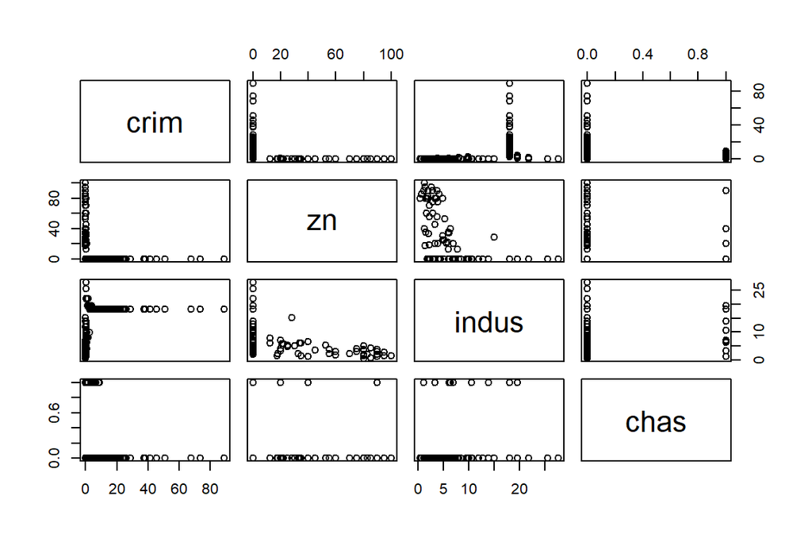

```r
pairs(Boston[1:4])
```

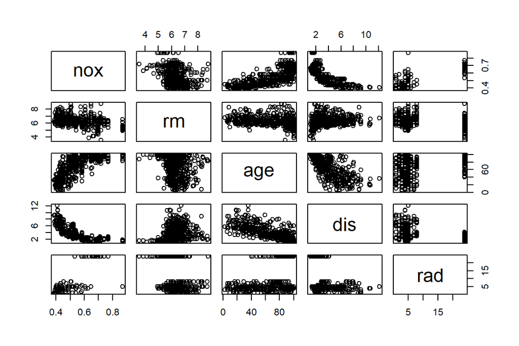

```r
pairs(Boston[5:9])
```

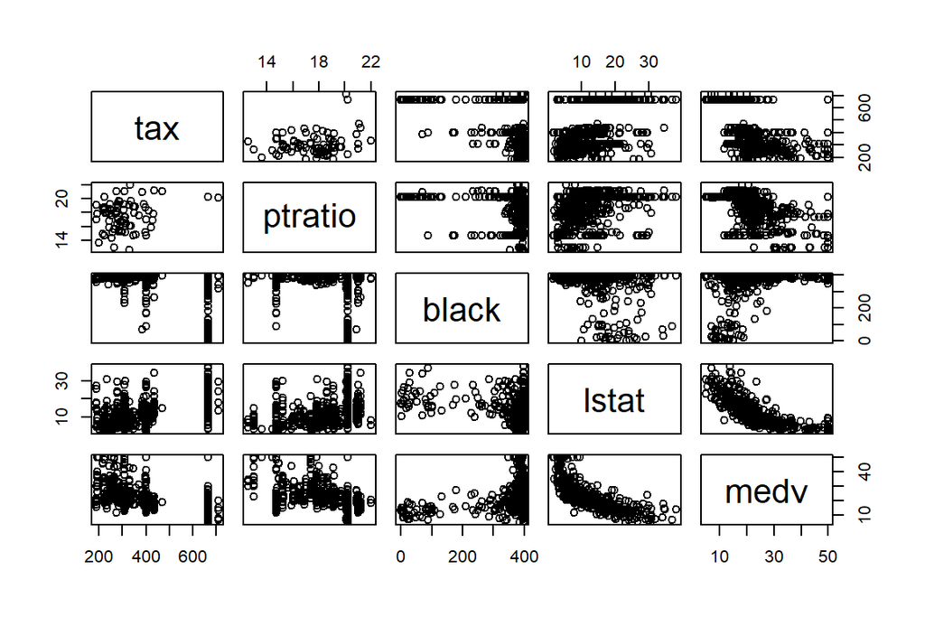

```r
pairs(Boston[10:14])
```

Zn and indus variables seem to have negative correlation (meaning where is residential land, there are no non-retailer business acres and vice versa). For example age and nox have positive vs age and dis have negative correlation.

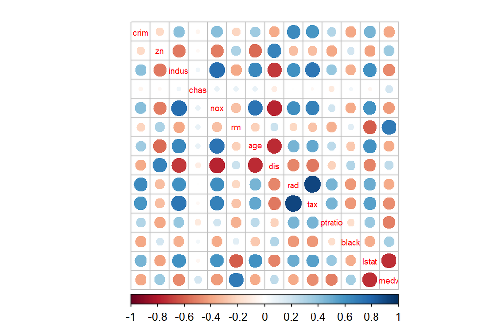

```r
cor_matrix<-cor(Boston) %>%
 round(digits = 2)
corrplot(cor_matrix, method="circle", cl.pos = "b", tl.pos = "d", tl.cex = 0.6)
```

Next, the data is standardized by decreasing the variable mean from each observation and dividing the number by sd. Therefore, each observation represents whether the real observation was bigger or smaller than the mean, and how far it was from the standard deviation.

```r
#Standardazing the data with z-scoring
boston_scaled <- scale(Boston)
summary(boston_scaled)
```

```
##       crim                 zn               indus              chas
##  Min.   :-0.419367   Min.   :-0.48724   Min.   :-1.5563   Min.   :-0.2723
##  1st Qu.:-0.410563   1st Qu.:-0.48724   1st Qu.:-0.8668   1st Qu.:-0.2723
##  Median :-0.390280   Median :-0.48724   Median :-0.2109   Median :-0.2723
##  Mean   : 0.000000   Mean   : 0.00000   Mean   : 0.0000   Mean   : 0.0000
##  3rd Qu.: 0.007389   3rd Qu.: 0.04872   3rd Qu.: 1.0150   3rd Qu.:-0.2723
##  Max.   : 9.924110   Max.   : 3.80047   Max.   : 2.4202   Max.   : 3.6648
##       nox                rm               age               dis
##  Min.   :-1.4644   Min.   :-3.8764   Min.   :-2.3331   Min.   :-1.2658
##  1st Qu.:-0.9121   1st Qu.:-0.5681   1st Qu.:-0.8366   1st Qu.:-0.8049
##  Median :-0.1441   Median :-0.1084   Median : 0.3171   Median :-0.2790
##  Mean   : 0.0000   Mean   : 0.0000   Mean   : 0.0000   Mean   : 0.0000
##  3rd Qu.: 0.5981   3rd Qu.: 0.4823   3rd Qu.: 0.9059   3rd Qu.: 0.6617
##  Max.   : 2.7296   Max.   : 3.5515   Max.   : 1.1164   Max.   : 3.9566
##       rad               tax             ptratio            black
##  Min.   :-0.9819   Min.   :-1.3127   Min.   :-2.7047   Min.   :-3.9033
##  1st Qu.:-0.6373   1st Qu.:-0.7668   1st Qu.:-0.4876   1st Qu.: 0.2049
##  Median :-0.5225   Median :-0.4642   Median : 0.2746   Median : 0.3808
##  Mean   : 0.0000   Mean   : 0.0000   Mean   : 0.0000   Mean   : 0.0000
##  3rd Qu.: 1.6596   3rd Qu.: 1.5294   3rd Qu.: 0.8058   3rd Qu.: 0.4332
##  Max.   : 1.6596   Max.   : 1.7964   Max.   : 1.6372   Max.   : 0.4406
##      lstat              medv
##  Min.   :-1.5296   Min.   :-1.9063
##  1st Qu.:-0.7986   1st Qu.:-0.5989
##  Median :-0.1811   Median :-0.1449
##  Mean   : 0.0000   Mean   : 0.0000
##  3rd Qu.: 0.6024   3rd Qu.: 0.2683
##  Max.   : 3.5453   Max.   : 2.9865
```

```r
boston_scaled <- as.data.frame(boston_scaled)
```

Calculating catecorical variable from crime, representing the crime rate

```r
bins <- quantile(boston_scaled$crim)
crime <- cut(boston_scaled$crim, breaks = bins, include.lowest = TRUE, label = c("low", "med_low", "med_high", "high"))
table(crime)
```

```
## crime
##      low  med_low med_high     high
##      127      126      126      127
```

```r
boston_scaled <- dplyr::select(boston_scaled, -crim)
boston_scaled <- data.frame(boston_scaled, crime)
```

Dividing data to test set and train set

```r
n <- nrow(boston_scaled)
ind <- sample(n,  size = n * 0.8)
train <- boston_scaled[ind,]
test <- boston_scaled[-ind,]
correct_classes <- test$crime
test <- dplyr::select(test, -crime)
```

Calculating linear discriminant analysis from the train data, by using crime rate as target variable.

```r
lda.fit <- lda(crime ~., data = train)
lda.fit
```

```
## Call:
## lda(crime ~ ., data = train)
##
## Prior probabilities of groups:
##       low   med_low  med_high      high
## 0.2599010 0.2623762 0.2351485 0.2425743
##
## Group means:
##                   zn       indus        chas        nox         rm        age
## low       0.88584906 -0.85875321 -0.12234430 -0.8538627  0.3872920 -0.8474553
## med_low  -0.07181736 -0.25804346  0.02481057 -0.5846093 -0.1599444 -0.4164985
## med_high -0.38704309  0.05900575  0.18354570  0.3164834  0.1153841  0.4007956
## high     -0.48724019  1.01719597 -0.11163110  1.0442824 -0.4453926  0.8209850
##                 dis        rad        tax     ptratio      black       lstat
## low       0.8288665 -0.6865511 -0.7464175 -0.40881278  0.3780817 -0.76040668
## med_low   0.4035051 -0.5614889 -0.4972948 -0.05528293  0.3154482 -0.13607816
## med_high -0.3310100 -0.4173090 -0.3659684 -0.25903504  0.1319803  0.01519602
## high     -0.8803346  1.6373367  1.5134896  0.77985517 -0.8925749  0.97215839
##                 medv
## low       0.46759577
## med_low  -0.01413229
## med_high  0.20141740
## high     -0.71153167
##
## Coefficients of linear discriminants:
##                  LD1          LD2         LD3
## zn       0.127173634  0.673647023 -0.92922811
## indus   -0.075595549 -0.002040160  0.59019895
## chas    -0.033135286 -0.052407918  0.14346115
## nox      0.503473478 -0.861557157 -1.17127575
## rm       0.045170830 -0.068110302 -0.12591745
## age      0.192916474 -0.395332723 -0.26326088
## dis     -0.165226503 -0.285724593  0.35520490
## rad      3.369428076  0.901141510 -0.15512098
## tax      0.002331758  0.007762282  0.50209826
## ptratio  0.161471855 -0.056528253 -0.25065257
## black   -0.133201372  0.022148571  0.08830255
## lstat    0.256414869 -0.310772350  0.39434327
## medv     0.098973009 -0.537045618 -0.12467838
##
## Proportion of trace:
##    LD1    LD2    LD3
## 0.9591 0.0295 0.0114
```

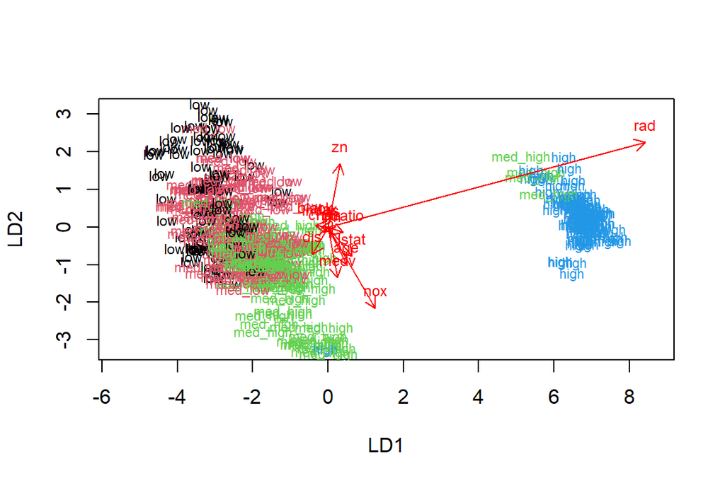

```
## integer(0)
```

```r
lda.arrows <- function(x, myscale = 1, arrow_heads = 0.1, color = "red", tex = 0.75, choices = c(1,2)){
  heads <- coef(x)
  arrows(x0 = 0, y0 = 0,
         x1 = myscale * heads[,choices[1]],
         y1 = myscale * heads[,choices[2]], col=color, length = arrow_heads)
  text(myscale * heads[,choices], labels = row.names(heads),
       cex = tex, col=color, pos=3)
}
classes <- as.numeric(train$crime)

plot(lda.fit, dimen = 2, col = classes, pch = classes)+
lda.arrows(lda.fit, myscale = 2.5)
```

The prediction capability of the algorithm is then tested using the test data.

```r
lda.pred <- predict(lda.fit, newdata = test)

table(correct = correct_classes, predicted = lda.pred$class)
```

```
##           predicted
## correct    low med_low med_high high
##   low       15       5        2    0
##   med_low    2       8       10    0
##   med_high   0       6       23    2
##   high       0       0        0   29
```

LDA prediction to test data leads to table above. The algorithm differentiates high crime rates well, but the accuracy is not that good what comes to low rates of crimes. Differentiating medium high and medium low -categories is hard, which might reveal something from the original data (e.g. the differences are not huge in there either).